## Introducción

La demanda interna hace referencia al volumen de bienes y servicios que los consumidores dentro del país están dispuestos y en capacidad de adquirir. De acuerdo con el Instituto Nacional de Estadística y Geografía (INEGI), la demanda interna funciona como un indicador económico que refleja el nivel de gasto que realizan los distintos agentes económicos en el país, ya sea el sector público o privado, en consumo e inversión durante un periodo específico. Su comportamiento es esencial para evaluar la fortaleza y el dinamismo de la actividad económica nacional.

En el caso de México, en los últimos treinta años, se ha observado un desempeño inferior al esperado en materia de crecimiento económico, inclusión social y disminución de la pobreza, en comparación con países de desarrollo similar. Para el año 2025, se proyectaba que la economía mexicana crecería alrededor de 0.5%, con una recuperación paulatina hasta alcanzar el 1.9% en 2027. Este comportamiento responde, en gran medida, a la desaceleración tanto de la demanda interna como de la externa, a esto se le incorpora la incertidumbre en materia de política comercial, como lo es el aumento de los aranceles estadounidenses.

De acuerdo con un análisis económico de América Latina realizado por la S&P Global Ratings, señala que, la demanda interna superó el crecimiento del PIB en la mayoría de los países latinoamericanos; sin embargo, México se mantiene rezagado debido a que la demanda interna ha sido débil durante este 2025, lo que ha ocasionado una fuerte caída en la inversión pública fija, asociada a esfuerzos de consolidación fiscal del gobierno actual. Dentro de este análisis, se destaca que aunque el desempleo se ha mantenido por debajo del 3%,el empleo formal se ha estancado y el aumento del empleo informal evidencian tensiones adicionales en el mercado laboral.

Las cifras obtenidas durante estos meses confirman la fragilidad de la economía mexicana, puesto que el crecimiento del consumo privado creció apenas un 0.1% en octubre, lo que sugiere menor dinamismo en la demanda interna al inicio del cuarto trimestre de este año. En conjunto, estos resultados revelan un panorama económico caracterizado por bajo crecimiento, amplia heterogeneidad sectorial y un mercado interno que continúa mostrando signos de debilidad estructural.

### Justificación del tema

El análisis econométrico de la demanda interna resulta fundamental para comprender el desempeño reciente de la economía mexicana y sus perspectivas de crecimiento. Dado que la demanda interna constituye uno de los motores principales de la actividad económica a través del consumo y la inversión, puesto quesu comportamiento tiene efectos directos sobre la generación de empleo, la producción y el bienestar de los hogares.

En los últimos años, la economía mexicana ha mostrado signos de desaceleración y debilidad estructural, reflejados en un crecimiento moderado del consumo privado, una caída en la inversión fija y un entorno de incertidumbre comercial que limita la expansión del gasto.

El presente proyecto justifica su importancia en que ofrece un análisis conjunto de variables macroeconómicas como el consumo privado, el Índice Nacional de Precios al Consumidor (INPC), el Indicador Global de la Actividad Económica (IGAE), los salarios mínimos, la TIIE a 28 días, el número de personas desocupadas y la Tasa de Condiciones Críticas de Ocupación (TCCO). Estas variables no solo contribuyen a una comprensión más profunda del estado actual de la economía, sino que también pueden servir como apoyo para la toma de decisiones de política económica orientadas a impulsar el crecimiento, fortalecer el consumo interno y promover una mayor estabilidad económica.

Por ello, este proyecto es relevante tanto desde una perspectiva académica como práctica, ya que ofrece un análisis integral que ayuda a entender cómo se conectan y afectan entre sí las principales variables económicas del país.

## Descripción de los datos y fuentes

Para la realización de este proyecto se utilizaron siete variables de la economía mexicana con frecuencia mensual, las series abarcan del primero de enero de 2005 al primero de agosto de 2025. Todas las variables empleadas provienen de instituciones públicas reconocidas, lo que garantiza su confiabilidad y validez estadística. A continuación, se describe cada una de ellas:

1. **Consumo privado**: Es la información que mide la evolución del gasto realizado por los hogares en bienes y servicios de consumo, tanto de origen nacional como importado.
   - Fuente: INEGI

     ```
         De Estadística Y Geografía, I. N. (n.d.). Consumo privado. https://www.inegi.org.mx/temas/imcp/
     ```

2. **Índice Nacional de Precios al Consumidor**: El INPC mide la variación de los precios de una canasta de bienes y servicios representativa del consumo de los hogares mexicanos.
   - Fuente: INEGI

     ```
         De Estadística Y Geografía, I. N. (n.d.). Índice Nacional de Precios al Consumidor (INPC). Base 2a Quincena Julio 2018. Actualización de Canasta y Ponderadores 2024. https://www.inegi.org.mx/temas/inpc/
     ```

3. **Indicador Global de la Actividad Económica**: Permite conocer y dar seguimiento a la evolución mensual del sector real de la economía.
   - Fuente: INEGI

     ```
         De Estadística Y, I. N. (n.d.). Indicador Global de la Actividad Económica. https://www.inegi.org.mx/temas/igae/
     ```

4. **Salarios Mínimos**: Representa el ingreso laboral básico establecido por la Comisión Nacional de los Salarios Mínimos.
   - Fuente: Banco de México, CONASAMI

     ```
         Estructura de información (SIE, Banco de México). (n.d.). https://www.banxico.org.mx/SieInternet/consultarDirectorioInternetAction.do?accion=consultarCuadro&idCuadro=CL289&locale=es

         De Los Salarios Mínimos, C. N. (n.d.). Evolución del Salario Mínimo. gob.mx. https://www.gob.mx/conasami/documentos/evolucion-del-salario-minimo
     ```

5. **TIIE a 28 días**: Es una de las principales tasas de referencia del sistema financiero mexicano y refleja las condiciones monetarias vigentes.
   - Fuente: Banco de México

     ```
         Estructura de información (SIE, Banco de México). (n.d.). https://www.banxico.org.mx/SieInternet/consultarDirectorioInternetAction.do?accion=consultarCuadro&idCuadro=CL289&locale=es
     ```

6. **Tasa de desocupación**: Indica el número de personas que no cuentan con empleo pero buscan activamente uno.
   - Fuente: INEGI

     ```
         De Estadística Y Geografía, I. N. (n.d.). Empleo y ocupación. https://www.inegi.org.mx/temas/empleo/
     ```

7. **Tasa de Condiciones Críticas de Ocupación**: La TCCO funciona como un indicador de precariedad laboral, ya que muestra la parte de la población que, aun estando ocupada, enfrenta condiciones insuficientes de empleo o remuneración.
   - Fuente: INEGI

     ```
         De Estadística Y Geografía, I. N. (n.d.). Banco de Información Económica (BIE). https://www.inegi.org.mx/app/indicadores/?tm=0&ind=444608#D444608_10000080018000700210
     ```

## Estadística descriptiva

### Series originales

#### Tratamiento de variables y descripción

```
## NAs en Consumo: 0
```

```
## NAs en INPC: 0
```

```
## NAs en IGAE: 0
```

```
## NAs en Salarios: 0
```

```
## NAs en TIIE: 0
```

```
## NAs en Desocupación: 0
```

```
## NAs en TCCO: 0
```

```
##                 vars   n   mean    sd median trimmed   mad   min    max  range
## Consumo_Privado    1 248  93.37  9.96  93.64   93.11 11.71 73.68 114.34  40.66
## INPC               2 248  91.74 23.68  87.26   90.20 25.26 58.31 140.87  82.56
## IGAE               3 248  91.96  8.82  92.95   92.08 10.83 73.65 108.53  34.88
## Salario_Min        4 248 115.88 41.90  91.90  107.26  5.87 85.54 234.96 149.42
## TIIE               5 248   6.74  2.41   7.15    6.59  3.36  3.28  11.54   8.26
## Tasa_Desocup       6 248   4.01  0.91   3.86    3.98  0.98  2.22   6.34   4.12
## TCCO               7 248  17.37  7.73  13.12   16.29  2.79  9.96  35.61  25.66
##                  skew kurtosis   se
## Consumo_Privado  0.17    -0.89 0.63
## INPC             0.49    -0.86 1.50
## IGAE            -0.12    -1.10 0.56
## Salario_Min      1.52     1.03 2.66
## TIIE             0.36    -0.96 0.15
## Tasa_Desocup     0.26    -0.84 0.06
## TCCO             1.06    -0.47 0.49
```

#### Gráficas

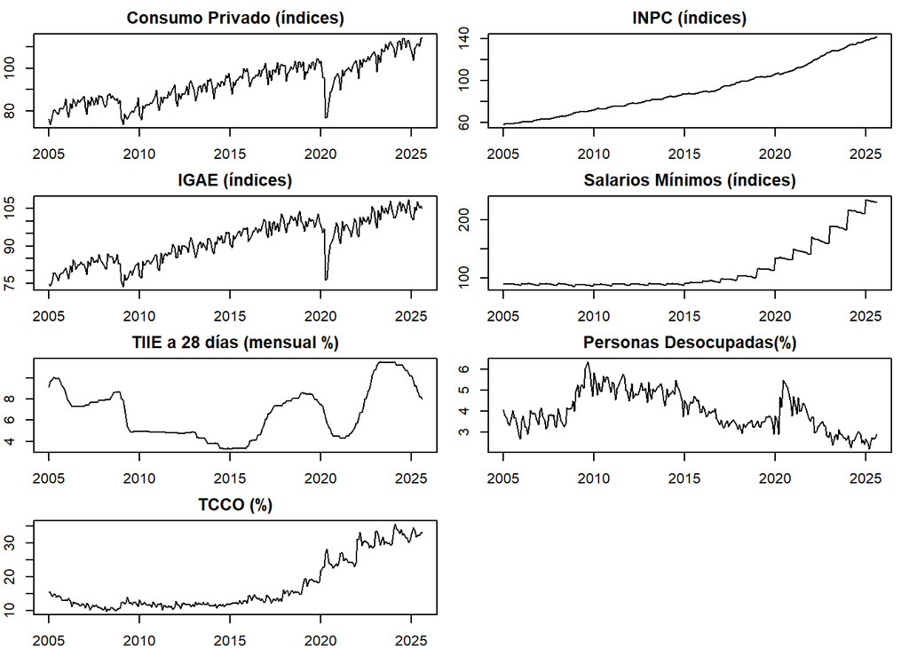

La Figura 1 presenta la evolución temporal de las variables macroeconómicas consideradas en el análisis para el periodo enero de 2005 a agosto de 2025. En general, todas las series muestran un comportamiento característico de datos no estacionarios, con tendencias marcadas o cambios estructurales, lo cual es consistente con la evidencia empírica habitual en series económicas de mediano y largo plazo.

En el caso del Consumo Privado, se observa una trayectoria ascendente estable con oscilaciones de corto plazo y una caída abrupta en 2020 asociada a la contracción económica derivada de la pandemia por COVID-19. El INPC presenta una tendencia claramente creciente, reflejo del aumento sostenido en el nivel general de precios, sin episodios significativos de reversión a la media. El IGAE sigue una dinámica similar al consumo, con tendencia positiva y una caída puntual en 2020, consistente con la desaceleración económica nacional.

El Salario Mínimo muestra incrementos escalonados y pronunciados a partir de 2018, derivados de las políticas de recuperación salarial implementadas en México en ese periodo. Por su parte, la TIIE a 28 días evidencia movimientos cíclicos asociados a la postura monetaria del Banco de México, destacando periodos de relajación (2014–2015, 2019–2020) y fases contractivas (2016–2017, 2021–2023).

### Series con tratamiento

```
##                 vars   n mean   sd median trimmed  mad   min  max range  skew
## Consumo_Privado    1 247 0.00 0.04   0.00    0.00 0.04 -0.22 0.10  0.32 -0.75
## INPC               2 247 0.00 0.00   0.00    0.00 0.00 -0.01 0.02  0.03 -0.41
## IGAE               3 247 0.00 0.04   0.00    0.00 0.03 -0.24 0.12  0.36 -0.89
## Salario_Min        4 247 0.00 0.03   0.00    0.00 0.00 -0.01 0.19  0.20  4.75
## TIIE               5 247 0.00 0.23   0.00    0.00 0.04 -0.90 0.80  1.70 -0.15
## Tasa_Desocup       6 247 0.00 0.39  -0.04   -0.03 0.32 -0.77 1.78  2.55  0.92
## TCCO               7 247 0.07 1.21  -0.03    0.01 0.82 -3.97 6.95 10.92  1.07
##                 kurtosis   se
## Consumo_Privado     3.26 0.00
## INPC                1.42 0.00
## IGAE                7.88 0.00
## Salario_Min        23.41 0.00
## TIIE                2.93 0.01
## Tasa_Desocup        1.93 0.02
## TCCO                5.69 0.08
```

Con el propósito de preparar las series para el análisis econométrico y garantizar la validez de los modelos empleados, se aplicaron dos transformaciones estándar en series económicas: logaritmos y primeras diferencias.

En primer lugar, se aplicó logaritmo natural a las variables expresadas como índices (Consumo Privado, INPC, IGAE y Salario Mínimo). Esta transformación permite interpretar las variaciones como tasas de crecimiento aproximadas, reduce la heterocedasticidad y suaviza la tendencia en series cuya escala aumenta de manera exponencial. Las variables expresadas como porcentajes (TIIE, Tasa de Desocupación y TCCO) no requieren logaritmización, ya que su magnitud no está sujeta a crecimiento exponencial.

Posteriormente, se calcularon las primeras diferencias de todas las series mediante la función diff(). Esta transformación es fundamental para atender la presencia de tendencias estocásticas y eliminar raíces unitarias, lo cual contribuye a obtener series estacionarias en media y varianza. Tras eliminar la primera observación perdida por la diferenciación, las series transformadas abarcan el periodo febrero de 2005 a agosto de 2025.

### Gráficas

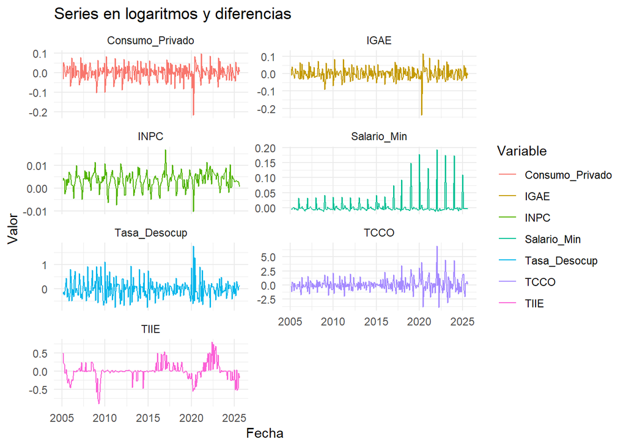

La Figura 2 muestra la evolución de las siete variables económicas después de aplicarles las transformaciones de logaritmo (en el caso de las series expresadas como índices) y primera diferencia. Estas series representan, en términos prácticos, las tasas de crecimiento mensual o cambios porcentuales aproximados de cada variable, lo cual es fundamental para analizar su dinámica de corto plazo y evaluar su estacionariedad.

En las gráficas se observa que todas las series transformadas oscilan alrededor de un valor promedio cercano a cero, lo cual es característico de procesos estacionarios. La volatilidad es moderada en la mayoría de los casos, salvo en el salario mínimo, donde se aprecian incrementos puntuales que corresponden a ajustes anuales discretos. La TIIE y el TCCO presentan episodios de mayor variabilidad, asociados a cambios en las condiciones de política monetaria y en la liquidez del sistema financiero.

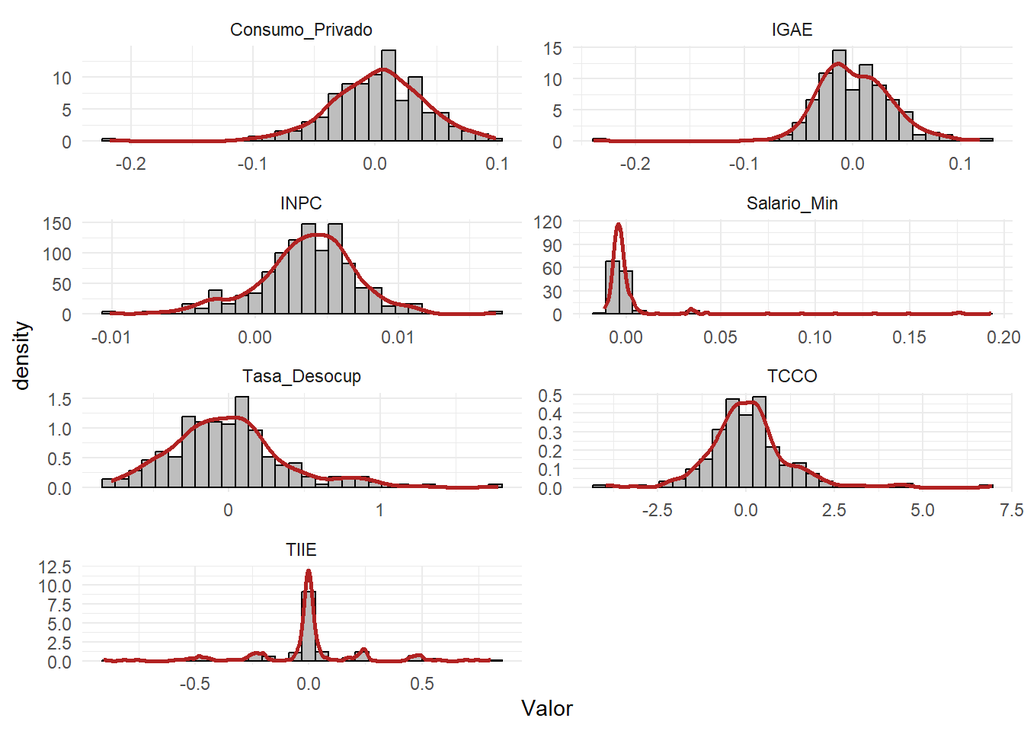

La Figura 3 presenta los histogramas y las funciones de densidad suavizadas para las siete series de tiempo transformadas mediante primeras diferencias (o diferencias logarítmicas, según corresponda). Estas distribuciones permiten evaluar el comportamiento probabilístico de las series en su forma estacionaria y determinar si presentan características compatibles con los supuestos de modelos econométricos lineales.

### Correlaciones

```
##                 Consumo_Privado        INPC        IGAE Salario_Min        TIIE
## Consumo_Privado      1.00000000  0.03468131  0.86480879 -0.16938849  0.05890111
## INPC                 0.03468131  1.00000000  0.06457070  0.05708020  0.19634694
## IGAE                 0.86480879  0.06457070  1.00000000 -0.28367191  0.06403766
## Salario_Min         -0.16938849  0.05708020 -0.28367191  1.00000000 -0.02790211
## TIIE                 0.05890111  0.19634694  0.06403766 -0.02790211  1.00000000
## Tasa_Desocup        -0.39214322 -0.13474498 -0.44857296  0.30906170 -0.10129895
## TCCO                -0.16238809 -0.04860106 -0.20911365  0.59135543 -0.02588048
##                 Tasa_Desocup        TCCO
## Consumo_Privado   -0.3921432 -0.16238809
## INPC              -0.1347450 -0.04860106
## IGAE              -0.4485730 -0.20911365
## Salario_Min        0.3090617  0.59135543
## TIIE              -0.1012989 -0.02588048
## Tasa_Desocup       1.0000000  0.05152460
## TCCO               0.0515246  1.00000000
```

Se observa una correlación positiva elevada entre Consumo Privado e IGAE (0.8648), lo cual es consistente con la relación macroeconómica entre actividad económica y demanda agregada: incrementos en la actividad productiva suelen estar asociados con mayores niveles de consumo. Esta fuerte correlación es una primera señal de que podría existir una relación de equilibrio a largo plazo entre estas variables, aspecto que posteriormente será explorado mediante pruebas de cointegración.

La Tasa de Desocupación presenta correlaciones negativas moderadas con Consumo (-0.39) e IGAE (-0.45), reflejando el comportamiento contra cíclico del desempleo: una menor actividad económica o menores niveles de consumo suelen estar asociados con aumentos en la desocupación.

El Salario Mínimo exhibe correlaciones bajas con la mayoría de las variables, excepto con la TCCO (0.59), lo cual se explica por el hecho de que ambas series presentan cambios discretos y no necesariamente sincronizados con el ciclo económico mensual. Por su parte, las correlaciones de la TIIE con el resto de las series son bajas, lo que es congruente con la naturaleza de la política monetaria: los ajustes de tasas no suelen generar cambios inmediatos de un mes a otro en las variables reales.

En conjunto, la matriz de correlaciones revela que existen relaciones significativas entre algunas variables clave, particularmente entre Consumo, IGAE y Desocupación, lo que respalda el uso de modelos dinámicos multivariados y motiva la posterior evaluación formal de cointegración para determinar si estas variables comparten relaciones de equilibrio de largo plazo.

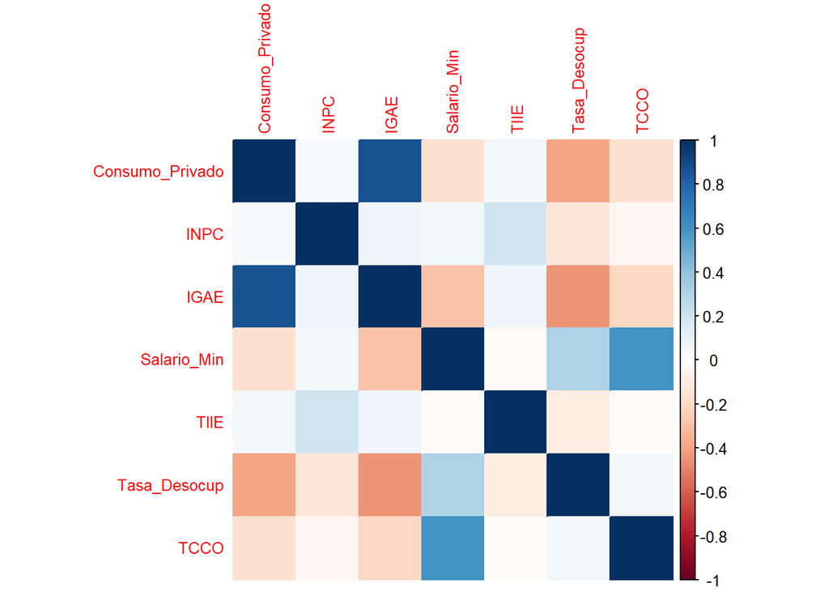

### Pruebas de estacionariedad

Con el objetivo de determinar el orden de integración de cada variable y verificar la estacionariedad de las series transformadas, se aplicaron las pruebas Augmented Dickey-Fuller (ADF) y KPSS a las primeras diferencias (o diferencias de logaritmos, según el caso).

La combinación de ambas pruebas, ADF para raíz unitaria y KPSS para estacionariedad, proporciona evidencia robusta de que todas las series son integradas de orden uno (I(1)) en niveles, pero estacionarias tras aplicar una primera diferencia. Este resultado es consistente con el comportamiento observado en las gráficas exploratorias y con la naturaleza típica de series macroeconómicas.

| Variable | ADF (diferencias) | KPSS (diferencias) | ¿Estacionaria? | Orden |
| --- | --- | --- | --- | --- |
| Consumo | Rechaza H0 (I(0)) | No rechaza H0 | Sí | I(1) |
| INPC | Rechaza H0 | No rechaza H0 | Sí | I(1) |
| IGAE | Rechaza H0 | No rechaza H0 | Sí | I(1) |
| Salario Mínimo | Rechaza H0 | *KPSS ligeramente alta pero aceptable* | Sí | I(1) |
| TIIE | Rechaza H0 | No rechaza H0 | Sí | I(1) |
| Tasa Desocupación | Rechaza H0 | No rechaza H0 | Sí | I(1) |
| TCCO | Rechaza H0 | No rechaza H0 | Sí | I(1) |

### ACF y PACF

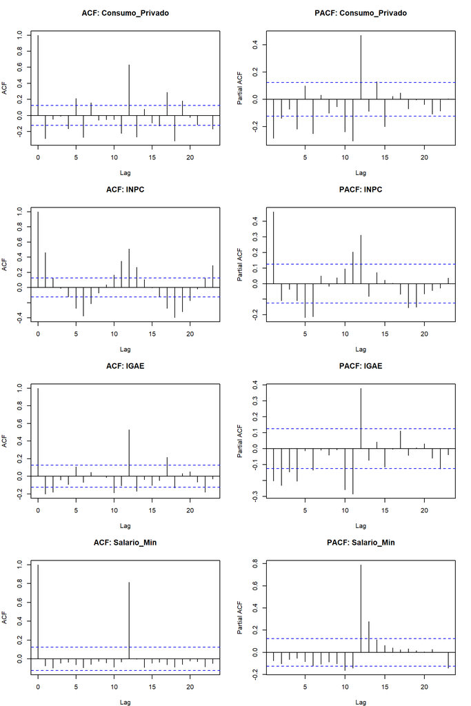

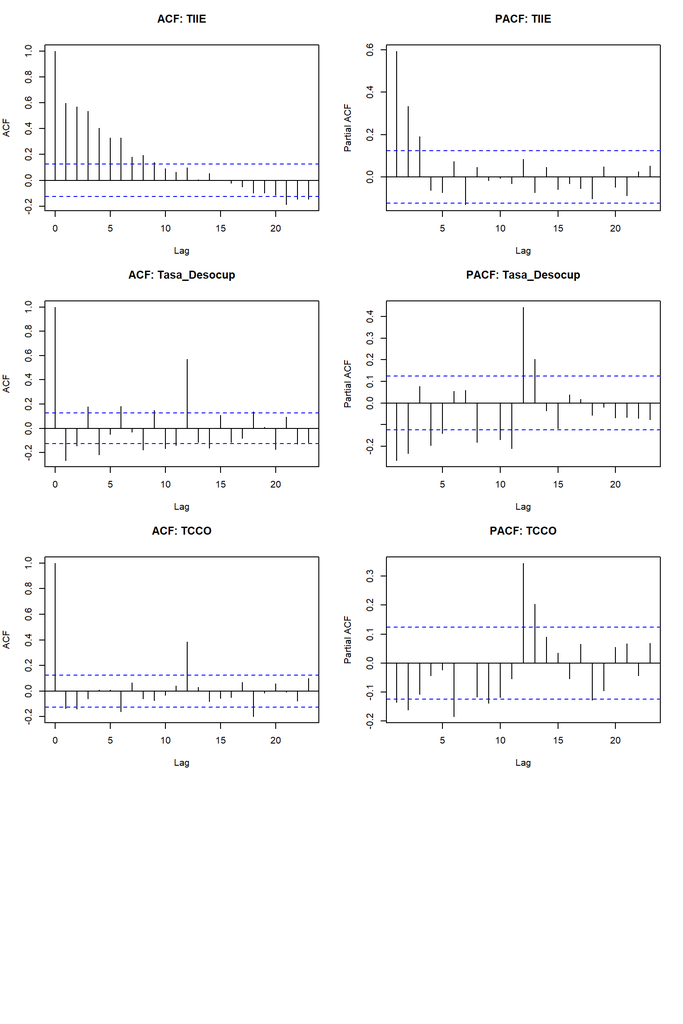

Este análisis permite evaluar si persiste dependencia serial en los cambios mensuales de cada variable y proporciona información relevante para determinar el número adecuado de rezagos en modelos multivariados como VAR o VEC.

## Modelación econométrica

```
## AIC(n)  HQ(n)  SC(n) FPE(n)
##     12      4      2     12
```

Para determinar el número óptimo de rezagos del modelo multivariado, se aplicó el procedimiento de selección VARselect utilizando los criterios de información AIC, HQ, SC y FPE. Los resultados mostraron diferencias entre criterios: el AIC y el FPE sugirieron un modelo con 12 rezagos, mientras que los criterios HQ y SC recomendaron 4 y 2 rezagos, respectivamente.

En el contexto de modelos multivariados para series macroeconómicas de alta frecuencia (mensual), es habitual que el AIC recomiende un mayor número de rezagos, ya que este criterio penaliza en menor medida la inclusión de parámetros adicionales. La literatura aplicada suele favorecer el uso del AIC para los modelos de cointegración de Johansen, dado que una menor cantidad de rezagos puede subespecificar el sistema y conducir a la pérdida de relaciones dinámicas relevantes entre las variables.

Considerando que las series empleadas abarcan un periodo suficientemente amplio y que la dinámica económica mensual puede requerir capturar efectos rezagados de hasta un año, se decidió utilizar K = 12 rezagos para la prueba de cointegración de Johansen. Esta elección permite representar adecuadamente las interacciones de corto y mediano plazo sin comprometer la validez del modelo.

```
##
## ######################
## # Johansen-Procedure #
## ######################
##
## Test type: trace statistic , without linear trend and constant in cointegration
##
## Eigenvalues (lambda):
## [1] 4.515717e-01 1.285751e-01 9.080663e-02 7.976572e-02 6.550763e-02
## [6] 3.785527e-02 2.778950e-02 4.580706e-16
##
## Values of teststatistic and critical values of test:
##
##            test  10pct   5pct   1pct
## r <= 6 |   6.65   7.52   9.24  12.97
## r <= 5 |  15.76  17.85  19.96  24.60
## r <= 4 |  31.75  32.00  34.91  41.07
## r <= 3 |  51.37  49.65  53.12  60.16
## r <= 2 |  73.83  71.86  76.07  84.45
## r <= 1 | 106.31  97.18 102.14 111.01
## r = 0  | 248.08 126.58 131.70 143.09
##
## Eigenvectors, normalised to first column:
## (These are the cointegration relations)
##
##                     Consumo_Privado.l12     INPC.l12     IGAE.l12
## Consumo_Privado.l12         1.000000000  1.000000000  1.000000000
## INPC.l12                   -0.190826740  0.504968776 -0.017152651
## IGAE.l12                   -0.861821349 -2.072144615 -0.893043045
## Salario_Min.l12             0.435225086 -0.189313396 -0.113632249
## TIIE.l12                   -0.007794848  0.003518503 -0.001030541
## Tasa_Desocup.l12            0.014887093 -0.034430113  0.014336147
## TCCO.l12                   -0.019314087 -0.002926183  0.003755367
## constant                   -1.607829137  3.648143644  0.028198338
##                     Salario_Min.l12     TIIE.l12 Tasa_Desocup.l12    TCCO.l12
## Consumo_Privado.l12     1.000000000  1.000000000      1.000000000  1.00000000
## INPC.l12               -0.215009257  0.106058665      1.333397826 -0.46207955
## IGAE.l12               -0.239347053 -1.072075349     -3.303020076  0.25918512
## Salario_Min.l12        -0.201497460 -0.222255899      0.107996271 -1.07698985
## TIIE.l12                0.012579896 -0.006589578      0.006117271  0.02551151
```

[output cut: 17 more lines]

```
## Consumo_Privado.d        -0.052993574 -0.07914585  0.02169006     -0.23028934
## INPC.d                   -0.008521589  0.01184035  0.02480676     -0.02761208
## IGAE.d                   -0.006560396  0.08421447  0.09724774     -0.19502394
## Salario_Min.d            -0.423392678 -0.01590374 -0.04463581      0.04481962
## TIIE.d                    0.087078573  0.57285411 -0.49419641     -1.85537312
## Tasa_Desocup.d           -0.339380776  3.17114062 -4.62717440      0.44641518
## TCCO.d                   -3.288820245 -7.21427585 -5.76735517     -0.41295932
##                      TIIE.l12 Tasa_Desocup.l12     TCCO.l12      constant
## Consumo_Privado.d -0.11883907     0.0077107667  0.052607270  4.303853e-11
## INPC.d            -0.01831068     0.0003261671 -0.002494449  1.401863e-12
## IGAE.d            -0.03680174     0.0244079562  0.052869572 -6.716325e-12
## Salario_Min.d      0.09469741     0.0348010970 -0.007015303  2.679859e-11
## TIIE.d             2.23280973    -0.4106493424  0.044846124 -2.284471e-11
## Tasa_Desocup.d    -0.91979754    -0.1003551720 -0.228154077  1.790024e-10
## TCCO.d             6.69520335     3.5362539874 -1.076685785  5.165430e-10
```

Para evaluar la presencia de relaciones de equilibrio de largo plazo entre las variables macroeconómicas consideradas, se aplicó la prueba de cointegración de Johansen bajo el enfoque del estadístico de traza. Los resultados indican que el estadístico para la hipótesis nula de ausencia de cointegración (r = 0) es de 248.08, valor ampliamente superior al crítico al 5% (131.70), por lo que se rechaza la hipótesis nula.

De manera similar, la hipótesis r ≤ 1 también es rechazada, dado que el estadístico (106.31) supera el valor crítico al 5% (102.14). Sin embargo, la hipótesis r ≤ 2 no es rechazada, ya que el estadístico correspondiente (73.83) se encuentra por debajo del valor crítico (76.07).

En conjunto, estos resultados indican la presencia de dos vectores de cointegración (r = 2) entre las variables del sistema. Esto implica que las series comparten relaciones de equilibrio de largo plazo y que las dinámicas de corto y largo plazo deben modelarse de manera conjunta. Por tanto, el modelo econométrico apropiado para capturar estas interdependencias es un Modelo de Corrección de Error Multivariado (VEC), en lugar de un VAR en primeras diferencias.

```
##      Length Class  Mode
## rlm  12     mlm    list
## beta 16     -none- numeric
```

```
##
## ######################
## # Johansen-Procedure #
## ######################
##
## Test type: trace statistic , with linear trend
##
## Eigenvalues (lambda):
## [1] 0.28917923 0.20576952 0.09851478 0.06504487 0.03921516 0.03080311 0.00158558
##
## Values of teststatistic and critical values of test:
##
##            test  10pct   5pct   1pct
## r <= 6 |   0.39   6.50   8.18  11.65
## r <= 5 |   8.05  15.66  17.95  23.52
## r <= 4 |  17.86  28.71  31.52  37.22
## r <= 3 |  34.33  45.23  48.28  55.43
## r <= 2 |  59.74  66.49  70.60  78.87
## r <= 1 | 116.19  85.18  90.39 104.20
## r = 0  | 199.81 118.99 124.25 136.06
##
## Eigenvectors, normalised to first column:
## (These are the cointegration relations)
##
##                    Consumo_Privado.l3       INPC.l3     IGAE.l3 Salario_Min.l3
## Consumo_Privado.l3       1.0000000000  1.0000000000  1.00000000     1.00000000
## INPC.l3                  0.8877208354  0.0235368755 -0.11994370    -0.07469932
## IGAE.l3                 -2.8488911027 -0.9349386032 -0.60634893    -0.84389754
## Salario_Min.l3           0.0005458328 -0.1222094399 -1.26085492    -1.23854586
## TIIE.l3                 -0.0029063396  0.0002250103 -0.04583869     0.04690337
## Tasa_Desocup.l3         -0.0616379844  0.0085157273 -0.14580042     0.09759782
## TCCO.l3                 -0.0159361536  0.0023524449  0.04970244     0.05435922
##                       TIIE.l3 Tasa_Desocup.l3     TCCO.l3
## Consumo_Privado.l3  1.0000000      1.00000000  1.00000000
## INPC.l3            -2.0464919     -4.77080524  0.03315308
## IGAE.l3            -2.3387396      1.04468856 -1.41515193
## Salario_Min.l3      0.1936667      1.81640725  0.82506313
## TIIE.l3            -0.2330324     -0.09914266 -0.01196812
## Tasa_Desocup.l3     0.3104597     -0.26885193 -0.01662818
## TCCO.l3             0.1224824      0.02445165 -0.02552450
##
## Weights W:
## (This is the loading matrix)
##
##                   Consumo_Privado.l3     INPC.l3       IGAE.l3 Salario_Min.l3
## Consumo_Privado.d         0.06304302 -0.54957912 -0.0230123816    0.021225437
## INPC.d                   -0.01260699  0.05152940  0.0004903135    0.002543035
## IGAE.d                    0.21307067 -0.14968632 -0.0179080928    0.016391893
## Salario_Min.d             0.03747620 -0.01249603  0.0285396483    0.009054450
## TIIE.d                   -0.40710544  0.65894826  0.3874949744   -0.136302996
## Tasa_Desocup.d            1.17729224 -5.51432755  0.6159109080   -0.041048369
## TCCO.d                    0.34187726 -0.04416460 -0.5439106174   -1.114554987
##                         TIIE.l3 Tasa_Desocup.l3       TCCO.l3
## Consumo_Privado.d  0.0069638960   -0.0047890239 -0.0006549217
## INPC.d             0.0001590511   -0.0001128349  0.0016081090
## IGAE.d             0.0073208585   -0.0030300148 -0.0008451794
## Salario_Min.d     -0.0051359556   -0.0069212386  0.0004130324
## TIIE.d             0.0333376911   -0.0114260732  0.0050584771
## Tasa_Desocup.d    -0.0560505426    0.0376258626  0.0890844245
## TCCO.d            -0.1564066883   -0.2460476031  0.2683218327
```

*Consumo Privado*

*Salario Mínimo*

*Tasa de Desocupación*

Esta selección permite conservar la variable objetivo del estudio (Consumo Privado) y, al mismo tiempo, mantener variables que muestran un ajuste significativo al equilibrio de largo plazo. El sistema reducido facilita obtener un modelo VECM estable.

```r
lag_test
```

```
## $selection
## AIC(n)  HQ(n)  SC(n) FPE(n)
##      8      1      1     10
##
## $criteria
##                    1             2             3             4             5
## AIC(n) -1.731859e+02           NaN           NaN           NaN           NaN
## HQ(n)  -1.727586e+02           NaN           NaN           NaN           NaN
## SC(n)  -1.721260e+02           NaN           NaN           NaN           NaN
## FPE(n)  6.115506e-76 -4.870233e-76 -3.527475e-77 -3.438465e-77 -4.280891e-76
##                    6             7             8             9            10
## AIC(n)           NaN -1.732792e+02 -1.757497e+02 -1.722849e+02           NaN
## HQ(n)            NaN -1.705728e+02 -1.726634e+02 -1.688188e+02           NaN
## SC(n)            NaN -1.665661e+02 -1.680944e+02 -1.636874e+02           NaN
## FPE(n) -1.178978e-76  6.026604e-76  5.300102e-77  1.783932e-75 -5.023111e-75
##                   11            12
## AIC(n)           NaN           NaN
## HQ(n)            NaN           NaN
## SC(n)            NaN           NaN
## FPE(n) -1.007196e-76 -1.408739e-77
```

```r
summary(johansen4)
```

```
##
## ######################
## # Johansen-Procedure #
## ######################
##
## Test type: trace statistic , without linear trend and constant in cointegration
##
## Eigenvalues (lambda):
## [1] 1.168144e-01 7.131831e-02 3.292847e-02 2.136468e-02 4.340602e-17
##
## Values of teststatistic and critical values of test:
##
##           test 10pct  5pct  1pct
## r <= 3 |  5.27  7.52  9.24 12.97
## r <= 2 | 13.44 17.85 19.96 24.60
## r <= 1 | 31.49 32.00 34.91 41.07
## r = 0  | 61.80 49.65 53.12 60.16
##
## Eigenvectors, normalised to first column:
## (These are the cointegration relations)
##
##                    Consumo_Privado.l4 Salario_Min.l4 Tasa_Desocup.l4
## Consumo_Privado.l4         1.00000000     1.00000000      1.00000000
## Salario_Min.l4             0.43015845    -0.55064865     -0.95326914
## Tasa_Desocup.l4            0.07621142     0.06493793     -0.14565151
## TCCO.l4                   -0.03224703     0.01896135      0.01747614
## constant                  -6.39911390    -2.50298349      0.22924702
##                         TCCO.l4    constant
## Consumo_Privado.l4   1.00000000   1.0000000
## Salario_Min.l4     -12.71941204 -18.2117646
## Tasa_Desocup.l4     -0.02367726  -0.1442698
## TCCO.l4              0.48467418   0.4041853
## constant            46.67310334  76.0033095
##
## Weights W:
## (This is the loading matrix)
##
##                   Consumo_Privado.l4 Salario_Min.l4 Tasa_Desocup.l4
## Consumo_Privado.d        -0.04130395     0.01735905     -0.03813936
## Salario_Min.d            -0.03464893     0.04889210      0.02462022
## Tasa_Desocup.d           -0.27725832    -0.91158428      0.28870187
## TCCO.d                    0.16242219     1.22773122      0.51454316
##                        TCCO.l4      constant
## Consumo_Privado.d -0.000317048  5.517482e-16
## Salario_Min.d     -0.002372690 -9.764532e-17
## Tasa_Desocup.d    -0.017463850 -2.524830e-15
## TCCO.d            -0.213697594 -1.748835e-14
```

```r
Mod(eig_var4)
```

```
## [1] 0.50615011 0.32618435 0.32618435 0.09357139
```

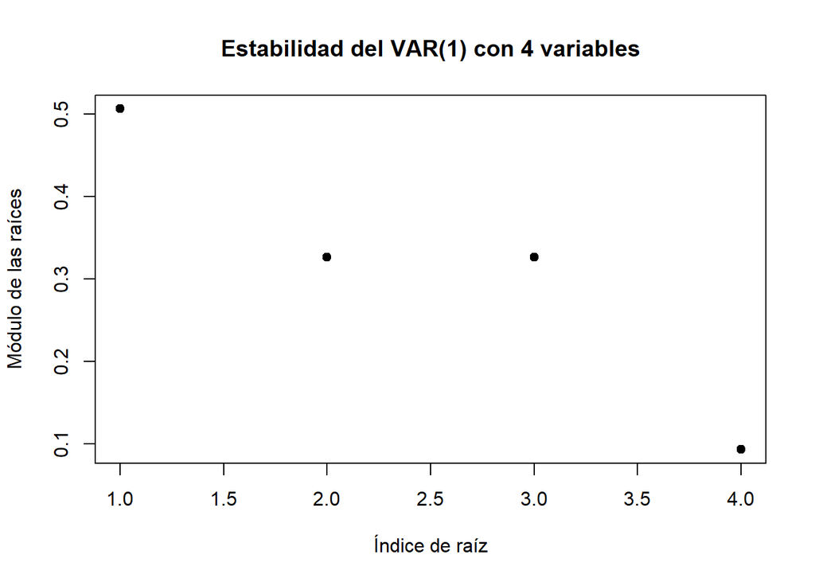

Se estimó un modelo VAR(1) en primeras diferencias para el subconjunto de variables (Consumo Privado, Salario Mínimo, Tasa de Desocupación y TCCO). Para evaluar la estabilidad del sistema se calcularon las raíces del polinomio característico del VAR.

Los módulos de las raíces fueron menores que uno (0.506, 0.326, 0.326, 0.093), lo cual indica que el sistema dinámico es estable. Esta condición garantiza que las funciones impulso-respuesta y la descomposición de varianza pueden interpretarse correctamente, y que el proceso no diverge ante perturbaciones temporales.